# MODULE 4 PROJECT

### ProdTaken Vs NumberOfTrips

```
ProdTaken         0    1   All
NumberOfTrips
All            3840  908  4748
2.0            1165  299  1464
3.0             862  217  1079
1.0             508  112   620
6.0             258   64   322
5.0             396   62   458
7.0             156   62   218
4.0             417   61   478
8.0              76   29   105
19.0              0    1     1
20.0              0    1     1
21.0              1    0     1
22.0              1    0     1
------------------------------------------------------------------------------------------------------------------------
```

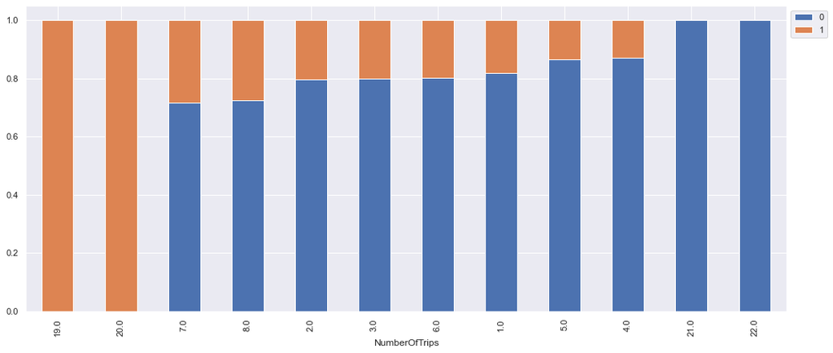

```python
stacked_plot(df.NumberOfTrips)  # to plot stacked barplot of ProdTaken and NumberOfTrips
```

- It can be observed from the barplot that customers that want to make either 19 or 20 trips per year are most likely to purchase travel packages but customers who want to make 21 or 22 trips a year are not likely to purchase any travel package. The table also shows that customer who plan to make 2 trips per year purchased the highest number of travel packages last year

### ProdTaken Vs Passport

```
ProdTaken     0    1   All
Passport
All        3968  920  4888
1           928  494  1422
0          3040  426  3466
------------------------------------------------------------------------------------------------------------------------
```

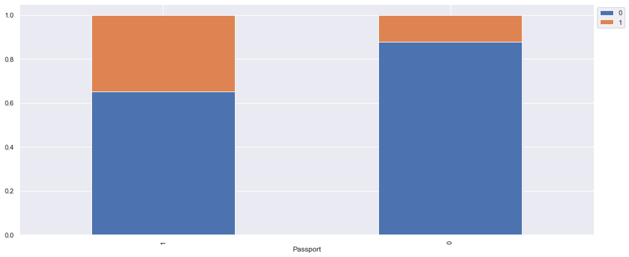

```python
stacked_plot(df.Passport)  # to plot stacked barplot of ProdTaken and Passport
```

- It can be observed that customers with passport are more likely to purchase travel package than customers without passport. Also customers with passport purchased more travel packages last year than customers without passport

### ProdTaken Vs OwnCar

```
ProdTaken     0    1   All
OwnCar
All        3968  920  4888
1          2472  560  3032
0          1496  360  1856
------------------------------------------------------------------------------------------------------------------------
```

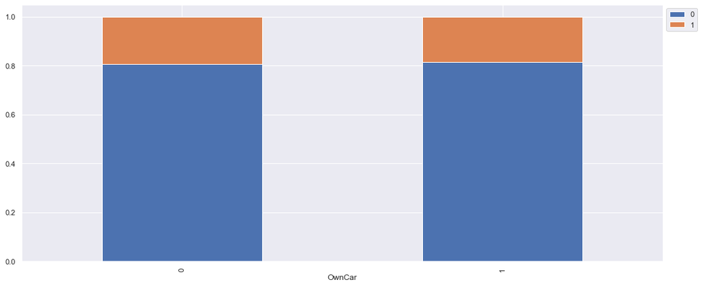

```python
stacked_plot(df.OwnCar)  # to plot stacked barplot of ProdTaken and OwnCar
```

- It can be observed that customers who are not car owners have slightly higher probability of purchasing a travel package than those who are car owners. However, customers who are car owners purchased more than half of the total travel packages sold last year.

### ProdTaken Vs NumberOfChildrenVisiting

```
ProdTaken                    0    1   All
NumberOfChildrenVisiting
All                       3909  913  4822
1.0                       1688  392  2080
2.0                       1082  253  1335
0.0                        880  202  1082
3.0                        259   66   325
------------------------------------------------------------------------------------------------------------------------
```

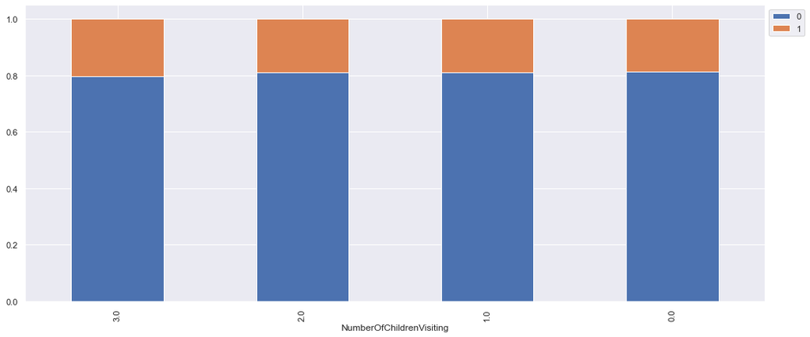

```python
stacked_plot(df.NumberOfChildrenVisiting)  # to plot stacked barplot of ProdTaken and NumberOfChildrenVisiting
```

- It can be observed from the barplot that the probability of a client purchasing a travel package is not significantly different regardless of the number of children(below 5 years old) planning to take the trip with the customer. Worthy of note also from the table above is that customers that took last year trips with just one child purchased the highest number of travel packages while those with 3 children purchased the least number of travel packages

### ProdTaken Vs Designation

```
ProdTaken          0    1   All
Designation
All             3968  920  4888
Executive       1290  552  1842
Manager         1528  204  1732
Senior Manager   618  124   742
AVP              322   20   342
VP               210   20   230
------------------------------------------------------------------------------------------------------------------------
```

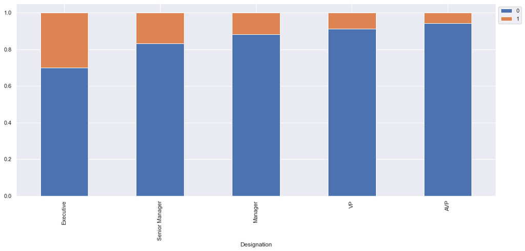

```python
stacked_plot(df.Designation)  # to plot stacked barplot of ProdTaken and Designation
```

- Customers with executive designation have approximately 30% likelihood of purchasing travel packages while others have below 20% probability. Customers with AVP designation have the least likelihood of purchasing travel packages. Also customers with executive designation purchased the highest number of travel packages last year

### ProdTaken Vs MonthlyIncome

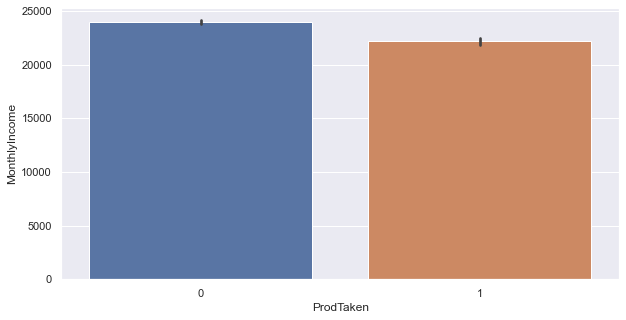

```python
# To plot a barplot of the ProdTaken Vs MonthlyIncome
plt.figure(figsize=(10, 5))
ax = sns.barplot(x='ProdTaken',y='MonthlyIncome', data=df)
plt.show()
```

### ProdTaken Vs PitchSatisfactionScore

```
ProdTaken                  0    1   All
PitchSatisfactionScore
All                     3968  920  4888
3                       1162  316  1478
5                        760  210   970
4                        750  162   912
1                        798  144   942
2                        498   88   586
------------------------------------------------------------------------------------------------------------------------
```

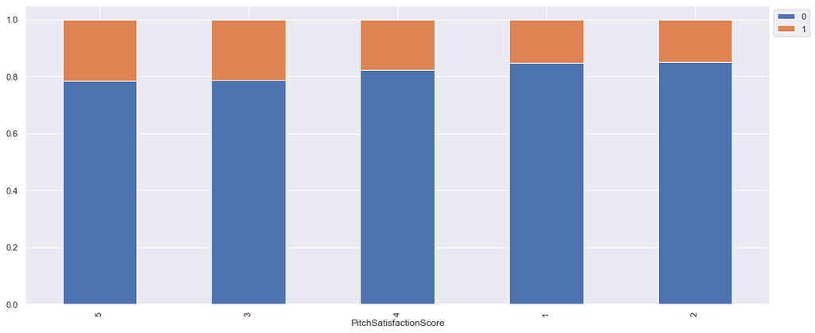

```python
stacked_plot(df.PitchSatisfactionScore)  # to plot stacked barplot of ProdTaken and PitchSatisfactionScore
```

- Customers with sales pitch satisfaction score 5 and 3 have higher likelihood of purchasing travel packages than other customers. Customers with sales pitch satisfaction score 2 have the least likelihood of purchasing travel package.

### ProdTaken Vs ProductPitched

```
ProdTaken          0    1   All
ProductPitched
All             3968  920  4888
Basic           1290  552  1842
Deluxe          1528  204  1732
Standard         618  124   742
King             210   20   230
Super Deluxe     322   20   342
------------------------------------------------------------------------------------------------------------------------
```

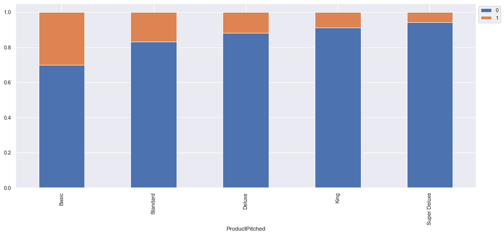

```python
stacked_plot(df.ProductPitched)  # to plot stacked barplot of ProdTaken and ProductPitched
```

- It can be observed that Basic product have the highest likelihood of being purchased among other products. Infact, Basic product accounted for 60% of the travel packages sold last year as shown in the table above. It appears that 'Basic' is the flagship product of the company as it sells the most while Super Deluxe is the least likely travel package to be purchased.

### ProdTaken Vs NumberOfFollowups

```
ProdTaken             0    1   All
NumberOfFollowups
All                3931  912  4843
4.0                1689  379  2068
3.0                1222  244  1466
5.0                 577  191   768
6.0                  82   54   136
2.0                 205   24   229
1.0                 156   20   176
------------------------------------------------------------------------------------------------------------------------
```

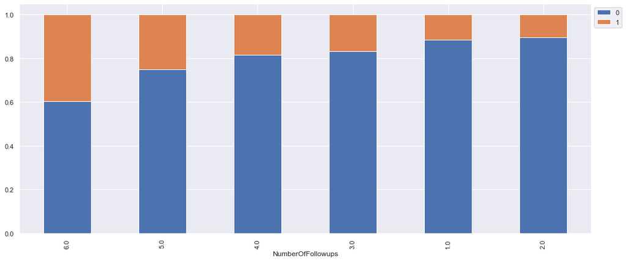

```python
stacked_plot(df.NumberOfFollowups)  # to plot stacked barplot of ProdTaken and NumberOfFollowups
```

- It appears that the likelihood of purchasing travel packages decreases with decrease in the number of follow-ups a salesperson gave to a customer. Customers that experienced 6 follow-ups from salespersons have the highest likelihood of purchasing travel package while customers that have only 2 follow-ups are least likely to purchase a travel package

### ProdTaken Vs DurationOfPitch

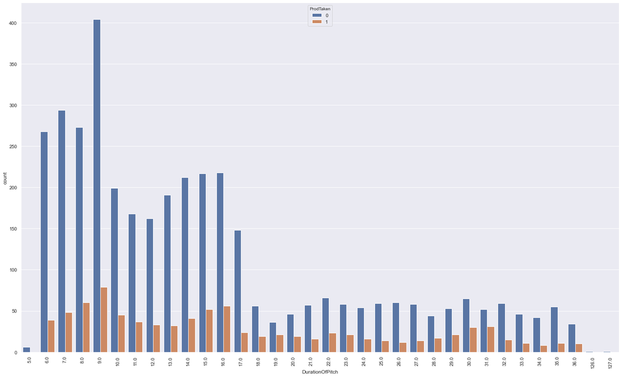

```python
# To plot a barplot of the ProdTaken Vs DurationOfPitch
plt.figure(figsize=(25, 15))
plt.xticks(rotation=90)
ax = sns.countplot(df.DurationOfPitch, hue=df.ProdTaken)
for p in ax.patches:
    x = p.get_x() + p.get_width() / 2 - 0.05  # width of the plot
    y = p.get_y() + p.get_height()  # hieght of the plot

plt.show()
```

- It can be observed that sales of travel packages keep increasing with increasing duration of sales pitch up to the 9th minutes after which the sales become unstable. Infact, sales pitch that extends beyond 36 minutes hardly leads to any sales of travel packages.

## Customer Profiling based on Products Pitched

**Let's see the profile of the customers based on products pitched**

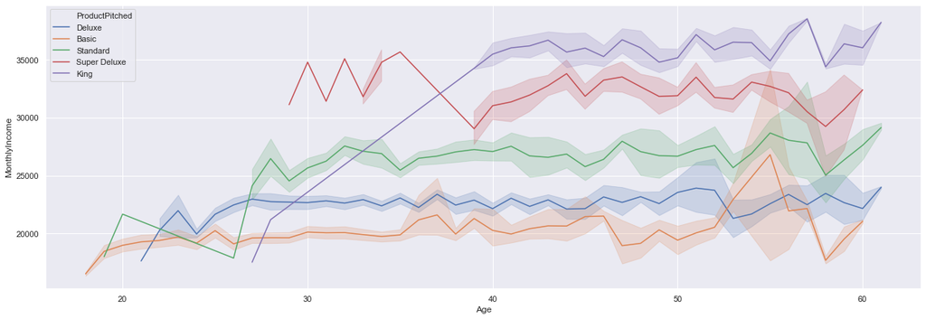

```python
sns.lineplot(x='Age',y='MonthlyIncome', data=df, hue= 'ProductPitched');#To check how ProductPitched varies with Age and MonthlyIncome of the customers
```

- It can be observed that income level of customers determine the product they go for. Customers with lowest income go for Basic while customers who purchased King package are generally high income earners. Also worthy of note is that customers below 26 years did not purchase Super Deluxe and King at all

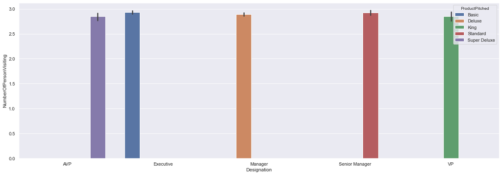

```python
sns.barplot(x='Designation',y='NumberOfPersonVisiting', data=df, hue= 'ProductPitched');# To check how product pitched vary along customer's designation and the number of person visiting with the client
```

- It can be observed that AVP customer prefers Super Deluxe, Executive client prefers Basic, Manager prefers Deluxe, Senior Manager goes Standard, VP goes for King

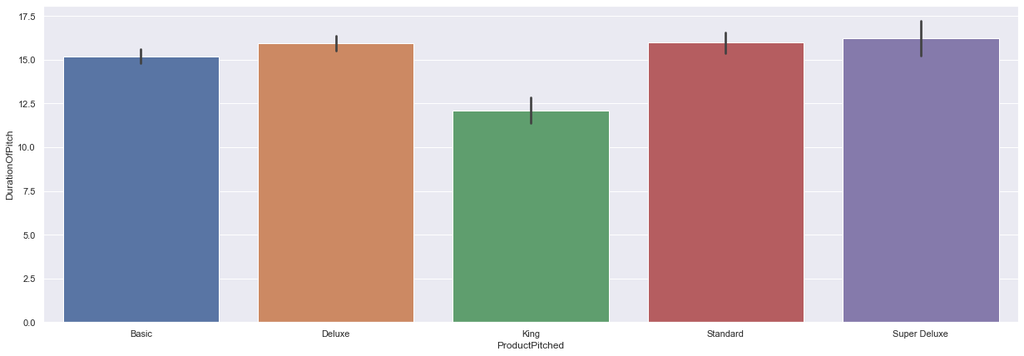

```python
sns.barplot(x='ProductPitched',y='DurationOfPitch', data=df);# To plot the DurationOfPitch against ProductPitched
```

- It can be observed that the 'King' takes less than 12.5 Duration of Pitch to sell while the remaining products take more than 15.0 duration of pitch to sell to customers

## Multivariate Analysis

### DurationOfPitch, MonthlyIncome and ProdTaken

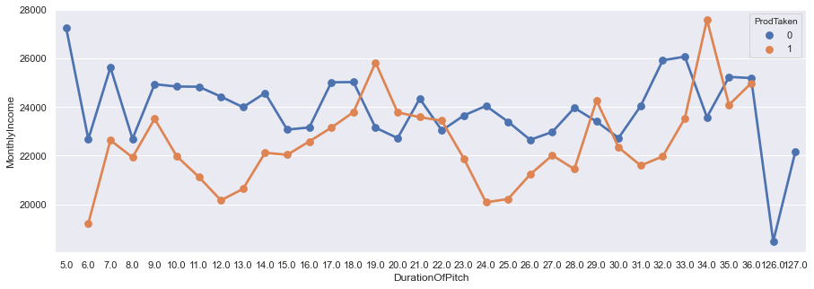

```python
# To plot a pointplot of the ProdTaken Vs DurationOfPitch and MonthlyIncome
plt.figure(figsize=(15,5))

sns.pointplot(x="DurationOfPitch", y="MonthlyIncome", hue = 'ProdTaken',  data=df, ci=None)
plt.show()
```

- It can be observed that a salesperson needs to spend a minimum of 19 minutes of sales pitch with customers earning above 24,000 monthly to be able to sell travel package to such customer. Customers earning above 24,000 monthly generally have lower tendencies of purchasing travel packages.

### Age, Occupation and ProdTaken

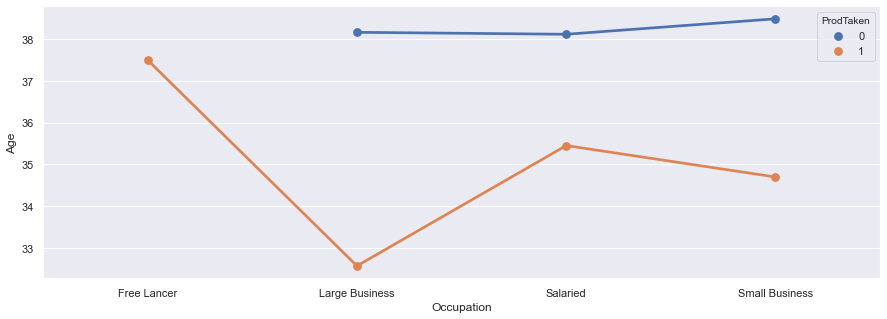

```python
# To plot a pointplot of the ProdTaken Vs Age and Occupation
plt.figure(figsize=(15,5))

sns.pointplot(x="Occupation", y="Age", hue = 'ProdTaken',  data=df, ci=None)
plt.show()
```

- It is clear from this plot that generally, customers that are more likely to purchase travel packages are below 38 years old irrespective of their occupation

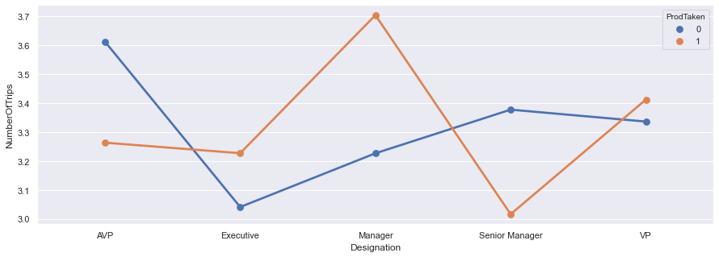

```python
# To plot a pointplot of the ProdTaken Vs Age and Occupation
plt.figure(figsize=(15,5))

sns.pointplot(x="Designation", y="NumberOfTrips", hue = 'ProdTaken',  data=df, ci=None)
plt.show()
```

- Most of the travel package purchasers who are of Manager Status embarked on the highest number of trips last year while their counterparts who are Senior Managers embarked on the lowest number of trips last year

### Treating the Missing Values

```python
df.isnull().sum()#To display the number of missing values in each feature again
```

```
ProdTaken                     0
Age                         226
TypeofContact                25
CityTier                      0
DurationOfPitch             251
Occupation                    0
Gender                        0
NumberOfPersonVisiting        0
NumberOfFollowups            45
ProductPitched                0
PreferredPropertyStar        26
MaritalStatus                 0
NumberOfTrips               140
Passport                      0
PitchSatisfactionScore        0
OwnCar                        0
NumberOfChildrenVisiting     66
Designation                   0
MonthlyIncome               233
dtype: int64
```

```python
#let's input the missing values in TypeofContact with another category called 'is_missing'
df['TypeofContact'] = df['TypeofContact'].cat.add_categories("is_missing").fillna("is_missing")
```

```python
df['TypeofContact'].value_counts()#To check the missing value imputation done in 'TypeofContact'
```

```
Self Enquiry       3444
Company Invited    1419
is_missing           25
Name: TypeofContact, dtype: int64
```

- The missing values in 'TypeofContact' has been taken care of now

```python
#Let's input the missing values in the remaining independent variables with the median value

numcol = [ 'Age', 'DurationOfPitch', 'NumberOfFollowups','PreferredPropertyStar','NumberOfTrips', 'NumberOfChildrenVisiting', 'MonthlyIncome']

for colname in numcol:
    df[colname] = df[colname].fillna(df[colname].median())
```

```python
df.isnull().sum()#Let's confirm if there is still any missing value or not
```

```
ProdTaken                   0
Age                         0
TypeofContact               0
CityTier                    0
DurationOfPitch             0
Occupation                  0
Gender                      0
NumberOfPersonVisiting      0
NumberOfFollowups           0
ProductPitched              0
PreferredPropertyStar       0
MaritalStatus               0
NumberOfTrips               0
Passport                    0
PitchSatisfactionScore      0
OwnCar                      0
NumberOfChildrenVisiting    0
Designation                 0
MonthlyIncome               0
dtype: int64
```

- There is no more missing values in the data set

## Model Building

```python
x = df.drop(
    ["ProdTaken"], axis=1
)  # defining the independent variables to refer to all other variables in the dataset aside 'ProdTaken'
y = df["ProdTaken"]  # defining the dependent variable to be 'ProdTaken'

x = pd.get_dummies(
    x, columns=x.select_dtypes(include=["category"]).columns.tolist(), drop_first=True
)  # Let's encode the categorical columns in the dataframe and drop the first dummy column in each variable

# Let's split the data into train and test sets with test size 30%
x_train, x_test, y_train, y_test = train_test_split(
    x, y, test_size=0.30, random_state=1,stratify=y)
```

```python
print(
    "Shape of Training set : ", x_train.shape
)  # to print the shape of the training set
print("Shape of test set : ", x_test.shape)  # to print the shape of the test set
print("*" * 30)  # to print a demarcation line
print("Percentage of classes in training set:")
print(
    y_train.value_counts(normalize=True)
)  # to print the percentage of each class in the y_train
print("*" * 30)  # to print a demarcation line
print("Percentage of classes in test set:")
print(
    y_test.value_counts(normalize=True)
)  # to print the percentage of each class in the y_train
```

```
Shape of Training set :  (3421, 29)
Shape of test set :  (1467, 29)
Percentage of classes in training set:
0    0.811751
1    0.188249
Name: ProdTaken, dtype: float64
Percentage of classes in test set:
0    0.811861
1    0.188139
Name: ProdTaken, dtype: float64
```

### Model evaluation criterion

### Model can make wrong predictions as:

1. Predicting a customer will purchase a travel package but actually did not .
2. Predicting a customer will not purchase a travel package but actually did

### Which case is more important?

- Both the cases are important as: a) If we predict a customer will purchase a travel package but actually did not purchase, the time and other resources used in marketing travel package to that customer will be a waste, thereby contributing to more marketing expenditure and its less efficiency. b) If we predict a customer will not purchase a travel package but did purchase, the Visit-With-Us's marketing department would have excluded such potential customer from their next marketing campaign.

### How to improve marketing expense efficiency i.e need to reduce misclassifications(both False Positives and False Negatives?

- `f1_score` should be maximized. The greater the f1_score, the higher the chances of identifying both the classes correctly.

**Fist, we will create two functions to calculate different metrics and confusion matrix.**

```python
##  Function to calculate different metric scores of the model - Accuracy, Recall, Precision, and F1_score
def model_perf(model,flag=True):

    # defining an empty list to store train and test results
    score_list=[]

    #Predicting on train and tests
    pred_train = model.predict(x_train)
    pred_test = model.predict(x_test)

    #Accuracy of the model
    train_acc = model.score(x_train,y_train)
    test_acc = model.score(x_test,y_test)

    #Recall of the model
    train_recall = metrics.recall_score(y_train,pred_train)
    test_recall = metrics.recall_score(y_test,pred_test)

    #Precision of the model
    train_precision = metrics.precision_score(y_train,pred_train)
    test_precision = metrics.precision_score(y_test,pred_test)

    #F1 of the model
    train_f1=metrics.f1_score(y_train,pred_train)
    test_f1= metrics.f1_score(y_test,pred_test)

    score_list.extend((train_acc,test_acc,train_recall,test_recall,train_precision,test_precision, train_f1, test_f1))

    # If the flag is set to True then only the following print statements will be dispayed. The default value is set to True.
    if flag == True:
        print("Accuracy on training set : ",model.score(x_train,y_train))
        print("Accuracy on test set : ",model.score(x_test,y_test))
        print("Recall on training set : ",metrics.recall_score(y_train,pred_train))
        print("Recall on test set : ",metrics.recall_score(y_test,pred_test))
        print("Precision on training set : ",metrics.precision_score(y_train,pred_train))
        print("Precision on test set : ",metrics.precision_score(y_test,pred_test))
        print('F1_Score on training set:', metrics.f1_score(y_train,pred_train))
        print('F1_Score on test set:',metrics.f1_score(y_test,pred_test))

    else:
        return score_list # returning the list with train and test scores
```

```python
# defining a function to plot the confusion_matrix of a classification model built
def conf_mat(model, predictors, target):
    """
    To plot the confusion_matrix with percentages

    model: classifier
    predictors: independent variables
    target: dependent variable
    """
    y_pred = model.predict(predictors)
    cm = confusion_matrix(target, y_pred)
    labels = np.asarray(
        [
            ["{0:0.0f}".format(item) + "\n{0:.2%}".format(item / cm.flatten().sum())]
            for item in cm.flatten()
        ]
    ).reshape(2, 2)

    plt.figure(figsize=(6, 4))
    sns.heatmap(cm, annot=labels, fmt="")
    plt.ylabel("Actual Class")
    plt.xlabel("Predicted Class")
```

### Building Decision Tree Model

```python
dtree = DecisionTreeClassifier(random_state=1)
dtree.fit(x_train, y_train)#fitting the decision tree model
```

```
DecisionTreeClassifier(ccp_alpha=0.0, class_weight=None, criterion='gini',
                       max_depth=None, max_features=None, max_leaf_nodes=None,
                       min_impurity_decrease=0.0, min_impurity_split=None,
                       min_samples_leaf=1, min_samples_split=2,
                       min_weight_fraction_leaf=0.0, presort='deprecated',
                       random_state=1, splitter='best')
```

```python
model_perf(dtree)#To check the performance of the decision tree model
```

```
Accuracy on training set :  1.0
Accuracy on test set :  0.8841172460804363
Recall on training set :  1.0
Recall on test set :  0.6811594202898551
Precision on training set :  1.0
Precision on test set :  0.6962962962962963
F1_Score on training set: 1.0
F1_Score on test set: 0.6886446886446886
```

- The model is overfitting on the train set and F1_Score of 0.69 on the test set is not too good

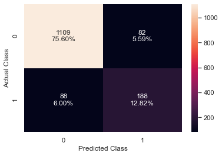

```python
conf_mat(dtree,x_test,y_test)#To plot the confusion matrix of the decision tree model
```

- From the confusion matrix, it is observed that the model wrongly predicted 82 customers as travel package purchaser and 88 as non-travel package purchaser. This misclassification is rather high.

### Bagging Classifier

```python
#To fit baggingclassifier model
bagging=BaggingClassifier(random_state=1)
bagging.fit(x_train,y_train)
```

```
BaggingClassifier(base_estimator=None, bootstrap=True, bootstrap_features=False,
                  max_features=1.0, max_samples=1.0, n_estimators=10,
                  n_jobs=None, oob_score=False, random_state=1, verbose=0,
                  warm_start=False)
```

```python
model_perf(bagging)#To check the performance of the bagging classifier model
```

```
Accuracy on training set :  0.9944460684010523
Accuracy on test set :  0.9134287661895024
Recall on training set :  0.9720496894409938
Recall on test set :  0.6195652173913043
Precision on training set :  0.9984051036682615
Precision on test set :  0.8860103626943006
F1_Score on training set: 0.985051140833989
F1_Score on test set: 0.7292110874200427
```

- The bagging classifier model also overfits but a little improvement is observed in the F1_Score on test set when compared to decision tree model

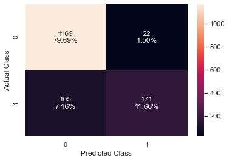

```python
conf_mat(bagging,x_test,y_test) #To plot confusion matrix of the baggin classifier model
```

- From the matrix above, it is clear that the bagging classifier model misclassified 105 travel package purchasers and 22 non-travel package purchasers. The model performs better than decision tree model in identifying customers that will not purchase travel package but performs worse in identifying those that will purchase travel packages

### Random Forest Classifier Model

```python
#To train the random forest classifier
rf_estimator=RandomForestClassifier(random_state=1)
rf_estimator.fit(x_train,y_train)
```

```
RandomForestClassifier(bootstrap=True, ccp_alpha=0.0, class_weight=None,
                       criterion='gini', max_depth=None, max_features='auto',
                       max_leaf_nodes=None, max_samples=None,
                       min_impurity_decrease=0.0, min_impurity_split=None,
                       min_samples_leaf=1, min_samples_split=2,
                       min_weight_fraction_leaf=0.0, n_estimators=100,
                       n_jobs=None, oob_score=False, random_state=1, verbose=0,
                       warm_start=False)
```

```python
#To check the performance of the random forest classifier model
rf_estimator_score=model_perf(rf_estimator)
rf_estimator_score
```

```
Accuracy on training set :  1.0
Accuracy on test set :  0.9134287661895024
Recall on training set :  1.0
Recall on test set :  0.5688405797101449
Precision on training set :  1.0
Precision on test set :  0.9515151515151515
F1_Score on training set: 1.0
F1_Score on test set: 0.7120181405895691
```

- It is clear that the model's performance is similar to that of bagging classifier. F1_Score of 0.71 is still not good enough

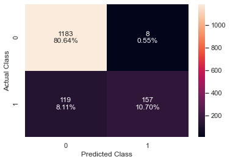

```python
conf_mat(rf_estimator,x_test,y_test) #Let's plot the confusion matrix of random forest classifier model
```

**With default parameters:**

- The three models -Decision tree, Bagging classifiers as well as random forest classifier are overfitting the train data.
- The three models are giving similar performance in terms of accuracy but bagging classifier is giving a slightly better F1_score.

## Hyperparameter Tuning

#### Let's perform some parameters tuning on the three models above

### Tuning Decision Tree Classifier

```python
# Let's tune the decision tree classifier.
dtree_tuned = DecisionTreeClassifier(criterion='gini',class_weight={0:0.19,1:0.81},random_state=1)

# Grid of parameters to choose from
parameters = {
    "max_depth": np.arange(1, 14),
    "min_samples_leaf": [1, 2, 5, 7, 10, 15, 20],
    "max_leaf_nodes": [2, 3, 5, 10],
    "min_impurity_decrease": [0.001, 0.01, 0.1],
}

# Using f1_score as metrics used to compare parameter combinations
acc_scorer = metrics.make_scorer(metrics.f1_score)

# Run the grid search
grid_obj = GridSearchCV(dtree_tuned, parameters, scoring=acc_scorer, cv=5)
grid_obj = grid_obj.fit(x_train, y_train)

# Set the classifier to the best combination of parameters
dtree_tuned = grid_obj.best_estimator_

# Fit the best algorithm to the data.
dtree_tuned.fit(x_train, y_train)
```

```
DecisionTreeClassifier(ccp_alpha=0.0, class_weight={0: 0.19, 1: 0.81},
                       criterion='gini', max_depth=3, max_features=None,
                       max_leaf_nodes=10, min_impurity_decrease=0.001,
                       min_impurity_split=None, min_samples_leaf=1,
                       min_samples_split=2, min_weight_fraction_leaf=0.0,
                       presort='deprecated', random_state=1, splitter='best')
```

```python
dtree_tuned_score=model_perf(dtree_tuned)
dtree_tuned_score
```

```
Accuracy on training set :  0.7901198479976616
Accuracy on test set :  0.8070892978868439
Recall on training set :  0.5667701863354038
Recall on test set :  0.5543478260869565
Precision on training set :  0.4539800995024876
Precision on test set :  0.48881789137380194
F1_Score on training set: 0.5041436464088398
F1_Score on test set: 0.5195246179966044
```

- Although the tuned decision tree did not overfit but its performance is worse than the earlier models with default parameters

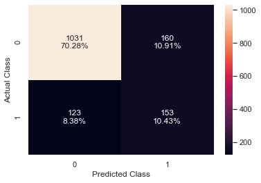

```python
conf_mat(dtree_tuned,x_test,y_test)#To plot the confusion matrix of the tuned decision tree
```

- The matrix further displays the poor performance of the model by showing the high misclassification of the customers. 160 non travel-package purchasers and 123 travel package purchasers are misclassified

### Tuning the Bagging Classifier

```python
# To tune the bagging classifier
bagging_estimator_tuned = BaggingClassifier(random_state=1)

# Grid of parameters to choose from
parameters = {'max_samples': [0.7,0.8,0.9,1],
              'max_features': [0.7,0.8,0.9,1],
              'n_estimators' : [10,20,30,40,50],
             }

# Type of scoring used to compare parameter combinations
acc_scorer = metrics.make_scorer(metrics.f1_score)

# Run the grid search
grid_obj = GridSearchCV(bagging_estimator_tuned, parameters, scoring=acc_scorer,cv=5)
grid_obj = grid_obj.fit(x_train, y_train)

# Set the classifier to the best combination of parameters
bagging_estimator_tuned = grid_obj.best_estimator_

# Fit the best algorithm to the data.
bagging_estimator_tuned.fit(x_train, y_train)
```

```
BaggingClassifier(base_estimator=None, bootstrap=True, bootstrap_features=False,
                  max_features=0.9, max_samples=0.9, n_estimators=50,
                  n_jobs=None, oob_score=False, random_state=1, verbose=0,
                  warm_start=False)
```

```python
#To check the performance of the tuned bagging classifier
bagging_estimator_tuned_score=model_perf(bagging_estimator_tuned)
bagging_estimator_tuned_score
```

```
Accuracy on training set :  0.9994153756211634
Accuracy on test set :  0.9250170415814588
Recall on training set :  0.9968944099378882
Recall on test set :  0.6485507246376812
Precision on training set :  1.0
Precision on test set :  0.9322916666666666
F1_Score on training set: 0.9984447900466563
F1_Score on test set: 0.764957264957265
```

- The tuned bagging classifier overfits the training set but shows an improved performance on test data when compared to all other previous models

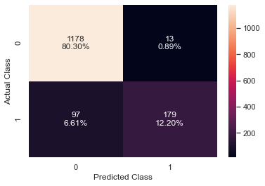

```python
conf_mat(bagging_estimator_tuned,x_test,y_test) #To plot a confusion matrix of the tuned bagging classifier
```

- The matrix above further confirms the improved performance of the model on test data as the number of misclassified customers has reduced to 13(customers that did not actually purchase travel package) and 97 (customers that actually purchase travel packages)

### Tuning Random Forest Classifier

```python
# To tune random forest classifier.
rf_estimator_tuned = RandomForestClassifier(class_weight={0:0.19,1:0.81},random_state=1)

# Grid of parameters to choose from
parameters = {"n_estimators": [150,200,250],
    "min_samples_leaf": np.arange(5, 10),
    "max_features": np.arange(0.2, 0.7, 0.1),
    "max_samples": np.arange(0.3, 0.7, 0.1),
             }

# Type of scoring used to compare parameter combinations
acc_scorer = metrics.make_scorer(metrics.f1_score)

# Running the grid search
grid_obj = GridSearchCV(rf_estimator_tuned, parameters, scoring=acc_scorer,cv=5)
grid_obj = grid_obj.fit(x_train, y_train)

# Setting the classifier to the best combination of parameters
rf_estimator_tuned = grid_obj.best_estimator_

# Fitting the best algorithm to the data.
rf_estimator_tuned.fit(x_train, y_train)
```

```
RandomForestClassifier(bootstrap=True, ccp_alpha=0.0,
                       class_weight={0: 0.19, 1: 0.81}, criterion='gini',
                       max_depth=None, max_features=0.4000000000000001,
                       max_leaf_nodes=None, max_samples=0.6000000000000001,
                       min_impurity_decrease=0.0, min_impurity_split=None,
                       min_samples_leaf=5, min_samples_split=2,
                       min_weight_fraction_leaf=0.0, n_estimators=200,
                       n_jobs=None, oob_score=False, random_state=1, verbose=0,
                       warm_start=False)
```

```python
#To check the performance of the tuned random forest classfier
rf_estimator_tuned_score=model_perf(rf_estimator_tuned)
rf_estimator_tuned_score
```

```
Accuracy on training set :  0.9427068108740134
Accuracy on test set :  0.8847989093387867
Recall on training set :  0.8990683229813664
Recall on test set :  0.6340579710144928
Precision on training set :  0.8154929577464789
Precision on test set :  0.720164609053498
F1_Score on training set: 0.8552437223042837
F1_Score on test set: 0.674373795761079
```

- The overfitting of the random forest model earlier built reduced a bit in the tuned random forest classifier. However, the tuned model performance on the test set is generally lower when compared with the earlier random forest model. F1_Score of 0.67 on the test set is still not good enough

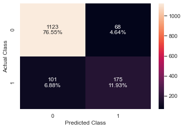

```python
conf_mat(rf_estimator_tuned,x_test,y_test)#To plot confusion matrix of the tuned random forest classifier on the test set
```

- The confusion matrix further confirms the poor performance of the tuned random forest classifier on the test data
- We will then explore some boosting methods and see if there will be a model with better performance on the test set especially

## Boosting Method

#### We shall build the boosting models with default parameters first and then perform some parameters tuning on them as well. f1_score shall remain our model performance evaluation metric as we want to reduce customer misclassification error to the bearest minimum level.

### Adaboost Classifier

```python
#Let's train adaboost classifier on the train set
abc=AdaBoostClassifier(random_state=1)
abc.fit(x_train,y_train)
```

```
AdaBoostClassifier(algorithm='SAMME.R', base_estimator=None, learning_rate=1.0,
                   n_estimators=50, random_state=1)
```

```python
#Let's check the performance of the adaboost model
abc_score=model_perf(abc)
abc_score
```

```
Accuracy on training set :  0.8439052908506285
Accuracy on test set :  0.8493524199045671
Recall on training set :  0.3198757763975155
Recall on test set :  0.32608695652173914
Precision on training set :  0.6821192052980133
Precision on test set :  0.72
F1_Score on training set: 0.4355179704016914
F1_Score on test set: 0.44887780548628436
```

- The model did not overfit but performs poorly on both train and test sets

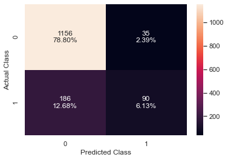

```python
conf_mat(abc,x_test,y_test)#To plot the confusion matrix of adaboost model on the test set
```

- The matrix further reveals the poor performance of the adaboost model

### Gradient Boosting Classifier

```python
#Let's train Gradient boosting classifier on the train set
gbc=GradientBoostingClassifier(random_state=1)
gbc.fit(x_train,y_train)
```

```
GradientBoostingClassifier(ccp_alpha=0.0, criterion='friedman_mse', init=None,
                           learning_rate=0.1, loss='deviance', max_depth=3,
                           max_features=None, max_leaf_nodes=None,
                           min_impurity_decrease=0.0, min_impurity_split=None,
                           min_samples_leaf=1, min_samples_split=2,
                           min_weight_fraction_leaf=0.0, n_estimators=100,
                           n_iter_no_change=None, presort='deprecated',
                           random_state=1, subsample=1.0, tol=0.0001,
                           validation_fraction=0.1, verbose=0,
                           warm_start=False)
```

```python
#Let's check the performance of the gradient boosting model
gbc_score=model_perf(gbc)
gbc_score
```

```
Accuracy on training set :  0.8854136217480268
Accuracy on test set :  0.8677573278800272
Recall on training set :  0.4440993788819876
Recall on test set :  0.39492753623188404
Precision on training set :  0.89375
Precision on test set :  0.8014705882352942
F1_Score on training set: 0.5933609958506224
F1_Score on test set: 0.529126213592233
```

- The gradient boosting model also shows a slightly better performance on the test set than the AdaBoost Classifier model. However, F1-Score of 0.53 is still not good enough

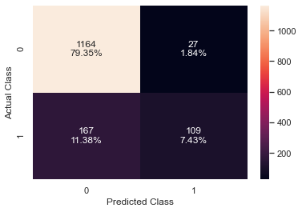

```python
conf_mat(gbc,x_test,y_test)#To plot the confusion matrix of GradientBoosting model on the test set
```

- The matrix displayed the poor performance of GradientBoosting model as well because the misclassified customers are still too many

### XGBoost Classifier

```python
#Let's train Extreme Gradient Boosting classifier on the train set
xgb=XGBClassifier(random_state=1,eval_metric='logloss')
xgb.fit(x_train,y_train)
```

```
XGBClassifier(base_score=0.5, booster='gbtree', colsample_bylevel=1,
              colsample_bynode=1, colsample_bytree=1, enable_categorical=False,
              eval_metric='logloss', gamma=0, gpu_id=-1, importance_type=None,
              interaction_constraints='', learning_rate=0.300000012,
              max_delta_step=0, max_depth=6, min_child_weight=1, missing=nan,
              monotone_constraints='()', n_estimators=100, n_jobs=4,
              num_parallel_tree=1, objective='binary:logistic',
              predictor='auto', random_state=1, reg_alpha=0, reg_lambda=1,
              scale_pos_weight=1, subsample=1, tree_method='exact',
              use_label_encoder=True, validate_parameters=1, ...)
```

```python
#Let's check the performance of the XGBoosting model
xgb_score=model_perf(xgb)
xgb_score
```

```
Accuracy on training set :  0.9994153756211634
Accuracy on test set :  0.9250170415814588
Recall on training set :  0.9968944099378882
Recall on test set :  0.6847826086956522
Precision on training set :  1.0
Precision on test set :  0.8915094339622641
F1_Score on training set: 0.9984447900466563
F1_Score on test set: 0.7745901639344263
```

- The XGBClassfier model overfits the training set but shows better performance on the test set than all other models earlier built. F1_Score of 0.77 on the test set is still the best gotten so far

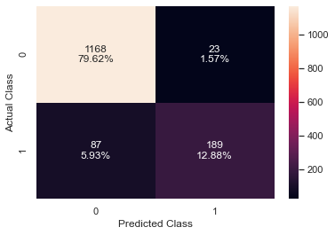

```python
conf_mat(xgb,x_test,y_test)#To plot the confusion matrix of XGBoosting model on the test set
```

**With default parameters:**

- XGBoost classifier has better test set performance among these 3 Boosting models.
- AdaBoost classifier has least test set performance across all the metrics.

### Hyperparameter Tuning of Boosting Classifiers

### Tuning the AdaBoost Classifier

```python
# To tune the AdaBoost Classifier
abc_tuned = AdaBoostClassifier(random_state=1)

# Grid of parameters to choose from
parameters = {
    #Let's try different max_depth for base_estimator
    "base_estimator":[DecisionTreeClassifier(max_depth=1, random_state=1),DecisionTreeClassifier(max_depth=2, random_state=1),DecisionTreeClassifier(max_depth=3, random_state=1)],
    "n_estimators": np.arange(10,110,10),
    "learning_rate":np.arange(0.1,2,0.1)
}

# Type of scoring used to compare parameter combinations
acc_scorer = metrics.make_scorer(metrics.f1_score)

# Running the grid search
grid_obj = GridSearchCV(abc_tuned, parameters, scoring=acc_scorer,cv=5)
grid_obj = grid_obj.fit(x_train, y_train)

# Setting the classifier to the best combination of parameters
abc_tuned = grid_obj.best_estimator_

# Fitting the best algorithm to the data.
abc_tuned.fit(x_train, y_train)
```

```
AdaBoostClassifier(algorithm='SAMME.R',
                   base_estimator=DecisionTreeClassifier(ccp_alpha=0.0,
                                                         class_weight=None,
                                                         criterion='gini',
                                                         max_depth=3,
                                                         max_features=None,
                                                         max_leaf_nodes=None,
                                                         min_impurity_decrease=0.0,
                                                         min_impurity_split=None,
                                                         min_samples_leaf=1,
                                                         min_samples_split=2,
                                                         min_weight_fraction_leaf=0.0,
                                                         presort='deprecated',
                                                         random_state=1,
                                                         splitter='best'),
                   learning_rate=1.0, n_estimators=100, random_state=1)
```

```python
#Let's check performance of the tuned AdaBoost model
abc_tuned_score=model_perf(abc_tuned)
abc_tuned_score
```

```
Accuracy on training set :  0.9891844489915229
Accuracy on test set :  0.89093387866394
Recall on training set :  0.9565217391304348
Recall on test set :  0.6485507246376812
Precision on training set :  0.9856
Precision on test set :  0.7396694214876033
F1_Score on training set: 0.9708431836091411
F1_Score on test set: 0.6911196911196912
```

- The model also overfits with a not-to-good f1_score of 0.69 on the test set

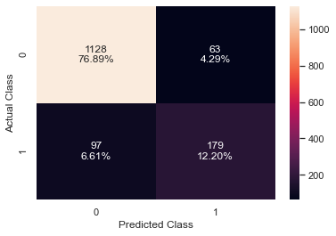

```python
conf_mat(abc_tuned,x_test,y_test) #To plot confusion matrix of the tuned adaboost model on the test set
```

### Insights

- The model is overfitting the train data as train accuracy is much higher than the test accuracy.
- The model has low test recall. This implies that the model is not good at identifying travel package purchasers.

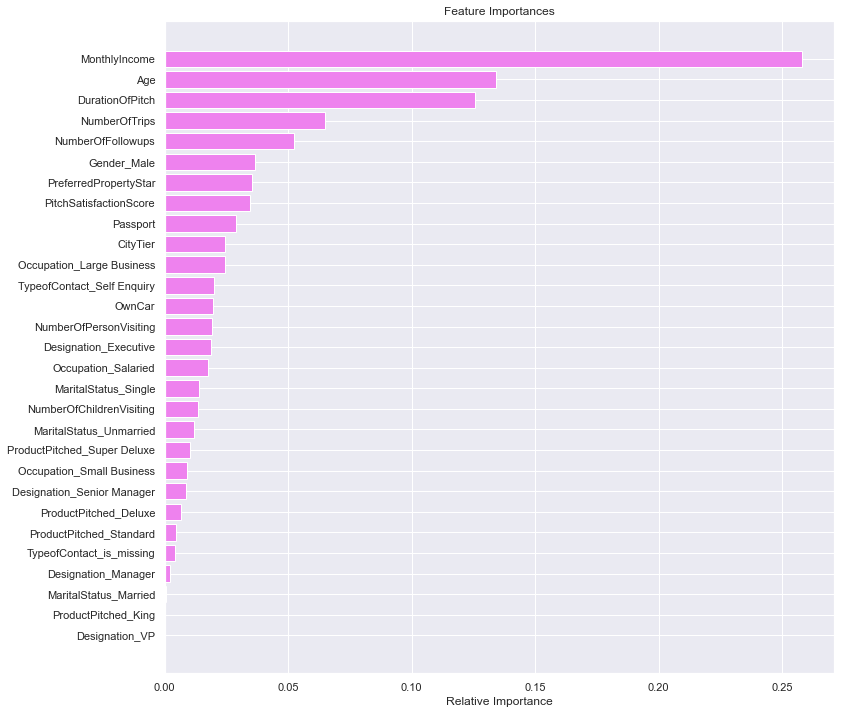

```python
#Let's check the importance of the independent variables
importances = abc_tuned.feature_importances_
indices = np.argsort(importances)
feature_names = list(x.columns)

plt.figure(figsize=(12,12))
plt.title('Feature Importances')
plt.barh(range(len(indices)), importances[indices], color='violet', align='center')
plt.yticks(range(len(indices)), [feature_names[i] for i in indices])
plt.xlabel('Relative Importance')
plt.show()
```

- MonthlyIncome,Age, and DurationOfPitch are the three most important features as per the tuned AdaBoost model.

### Tuning the GradientBoosting Classifier

```python
# To tune the GradientBoosting Classifier
gbc_tuned = GradientBoostingClassifier(init=AdaBoostClassifier(random_state=1),random_state=1)

# Grid of parameters to choose from

parameters = {
    "n_estimators": [100,150,200,250],
    "subsample":[0.8,0.9,1],
    "max_features":[0.7,0.8,0.9,1]
}

# Usinf f1_score to compare parameter combinations
acc_scorer = metrics.make_scorer(metrics.f1_score)

# Running the grid search
grid_obj = GridSearchCV(gbc_tuned, parameters, scoring=acc_scorer,cv=5)
grid_obj = grid_obj.fit(x_train, y_train)

# Setting the classifier to the best combination of parameters
gbc_tuned = grid_obj.best_estimator_

# Fitting the best algorithm to the data.
gbc_tuned.fit(x_train, y_train)
```

```
GradientBoostingClassifier(ccp_alpha=0.0, criterion='friedman_mse',
                           init=AdaBoostClassifier(algorithm='SAMME.R',
                                                   base_estimator=None,
                                                   learning_rate=1.0,
                                                   n_estimators=50,
                                                   random_state=1),
                           learning_rate=0.1, loss='deviance', max_depth=3,
                           max_features=0.9, max_leaf_nodes=None,
                           min_impurity_decrease=0.0, min_impurity_split=None,
                           min_samples_leaf=1, min_samples_split=2,
                           min_weight_fraction_leaf=0.0, n_estimators=250,
                           n_iter_no_change=None, presort='deprecated',
                           random_state=1, subsample=0.8, tol=0.0001,
                           validation_fraction=0.1, verbose=0,
                           warm_start=False)
```

```python
#To check the performance of the tuned gradient boosting model
gbc_tuned_score=model_perf(gbc_tuned)
gbc_tuned_score
```

```
Accuracy on training set :  0.9207833966676411
Accuracy on test set :  0.8868438991138378
Recall on training set :  0.6164596273291926
Recall on test set :  0.5036231884057971
Precision on training set :  0.9429928741092637
Precision on test set :  0.8273809523809523
F1_Score on training set: 0.7455399061032865
F1_Score on test set: 0.6261261261261261
```

- The tuned gradient boosting model also does not show good performance on the test set with a recall of 0.50 and f1_score of 0.63

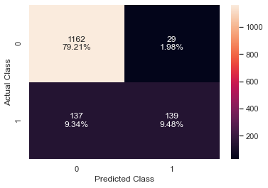

```python
conf_mat(gbc_tuned,x_test,y_test)#To plot the confusion matrix of the tuned gradientboosting model
```

- The tuned gradient boosting model is able to identify 139 out of 276 travel package purchasers and 1162 out of 1191 non-travel package purchasers. This is not a good performance

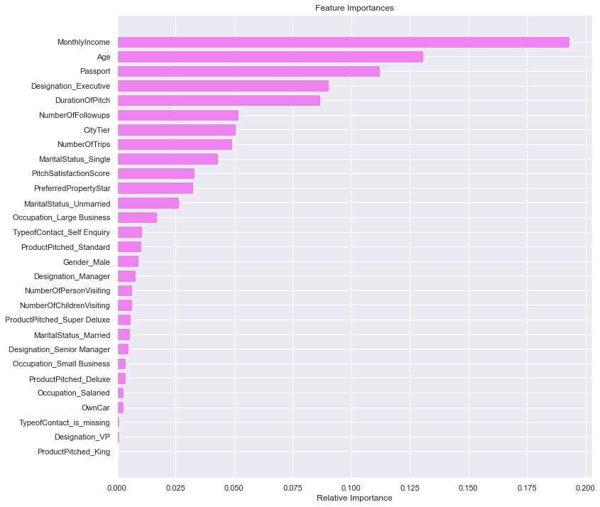

```python
#To check the importance of each independent variable
importances = gbc_tuned.feature_importances_
indices = np.argsort(importances)
feature_names = list(x.columns)

plt.figure(figsize=(12,12))
plt.title('Feature Importances')
plt.barh(range(len(indices)), importances[indices], color='violet', align='center')
plt.yticks(range(len(indices)), [feature_names[i] for i in indices])
plt.xlabel('Relative Importance')
plt.show()
```

- The gradient boosting model shows that MonthlyIncome, Age, and Passport are the three most important features determining customers that will purchase travel packages

### Tuning the XGBoost Classifier

```python
# to tune the XGBoost classifier.
xgb_tuned = XGBClassifier(random_state=1,eval_metric='logloss')

# Grid of parameters to choose from
parameters = {'n_estimators': [75,100,125,150],
              'subsample':[0.7, 0.8, 0.9, 1],
              'gamma':[0, 1, 3, 5],
              'colsample_bytree':[0.7, 0.8, 0.9, 1],
              'colsample_bylevel':[0.7, 0.8, 0.9, 1]
              }

# Using f1_score to compare parameter combinations
acc_scorer = metrics.make_scorer(metrics.f1_score)

# Running the grid search
grid_obj = GridSearchCV(xgb_tuned, parameters,scoring=acc_scorer,cv=5)
grid_obj = grid_obj.fit(x_train, y_train)

# Setting the classifier to the best combination of parameters
xgb_tuned = grid_obj.best_estimator_

# Fitting the best algorithm to the data.
xgb_tuned.fit(x_train, y_train)
```

```
XGBClassifier(base_score=0.5, booster='gbtree', colsample_bylevel=0.7,
              colsample_bynode=1, colsample_bytree=0.8,
              enable_categorical=False, eval_metric='logloss', gamma=0,
              gpu_id=-1, importance_type=None, interaction_constraints='',
              learning_rate=0.300000012, max_delta_step=0, max_depth=6,
              min_child_weight=1, missing=nan, monotone_constraints='()',
              n_estimators=150, n_jobs=4, num_parallel_tree=1,
              objective='binary:logistic', predictor='auto', random_state=1,
              reg_alpha=0, reg_lambda=1, scale_pos_weight=1, subsample=1,
              tree_method='exact', use_label_encoder=True,
              validate_parameters=1, ...)
```

```python
#To check the performance of the tuned XGBoost classifier
xgb_tuned_score=model_perf(xgb_tuned)
xgb_tuned_score
```

```
Accuracy on training set :  1.0
Accuracy on test set :  0.9331970006816632
Recall on training set :  1.0
Recall on test set :  0.7318840579710145
Precision on training set :  1.0
Precision on test set :  0.8938053097345132
F1_Score on training set: 1.0
F1_Score on test set: 0.804780876494024
```

- The tuned XGBClassifier model is overfitting on the train set as well but gave the best performance on the test set out of all the earlier models built

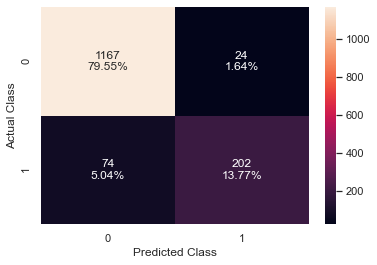

```python
conf_mat(xgb_tuned,x_test,y_test)#To plot the confusion matrix of tuned XGBoost classifier
```

- The model is able to identify 202 out of 276 travel package purchaser which is the highest so far

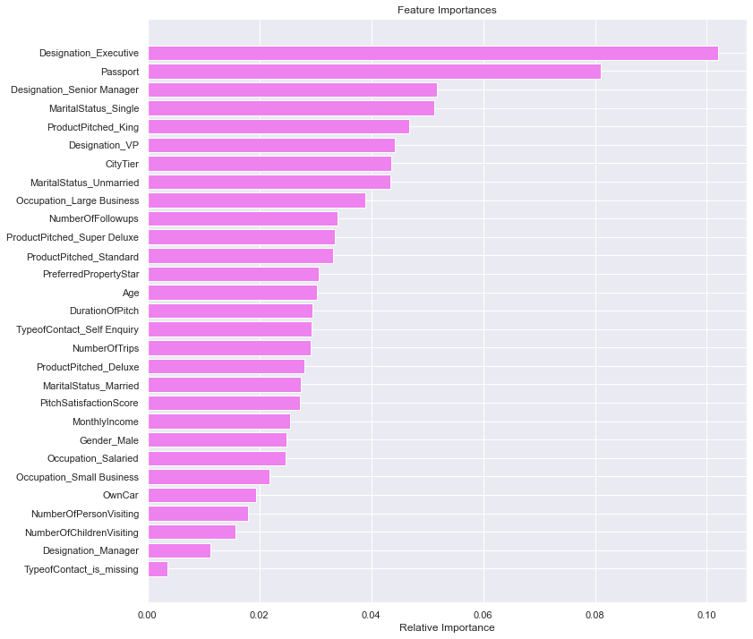

```python
#To plot the importances of all the independent variable
importances = xgb_tuned.feature_importances_
indices = np.argsort(importances)
feature_names = list(x.columns)

plt.figure(figsize=(12,12))
plt.title('Feature Importances')
plt.barh(range(len(indices)), importances[indices], color='violet', align='center')
plt.yticks(range(len(indices)), [feature_names[i] for i in indices])
plt.xlabel('Relative Importance')
plt.show()
```

- Executive Designation, Passport, and Senior Manager are the three most important features determining a customer that will likely purchase a travel package according to the tuned XGBoost model

### Stacking Classifier

**Now, let's build a stacking model with the tuned models - bagging, adaboost, and gradient boosting, then use XGBoost to get the final prediction.**

```python
#Defining the models to stack together

estimators=[('Bagging', bagging_estimator_tuned),('Adaboost', abc_tuned),
           ('Gradient Boosting', gbc_tuned)]
final_estimator=XGBClassifier(random_state=1,eval_metric='logloss')#defining the classifier for final prediction
```

```python
#to train the stacking classifier on the train set
stacking_estimator=StackingClassifier(estimators=estimators, final_estimator=final_estimator,cv=5)
stacking_estimator.fit(x_train,y_train)
```

```
StackingClassifier(cv=5,
                   estimators=[('Bagging',
                                BaggingClassifier(base_estimator=None,
                                                  bootstrap=True,
                                                  bootstrap_features=False,
                                                  max_features=0.9,
                                                  max_samples=0.9,
                                                  n_estimators=50, n_jobs=None,
                                                  oob_score=False,
                                                  random_state=1, verbose=0,
                                                  warm_start=False)),
                               ('Adaboost',
                                AdaBoostClassifier(algorithm='SAMME.R',
                                                   base_estimator=DecisionTreeClassifier(ccp_alpha=0.0,
                                                                                         c...
                                                 min_child_weight=None,
                                                 missing=nan,
                                                 monotone_constraints=None,
                                                 n_estimators=100, n_jobs=None,
                                                 num_parallel_tree=None,
                                                 objective='binary:logistic',
                                                 predictor=None, random_state=1,
                                                 reg_alpha=None,
                                                 reg_lambda=None,
                                                 scale_pos_weight=None,
                                                 subsample=None,
                                                 tree_method=None,
                                                 use_label_encoder=True,
                                                 validate_parameters=None, ...),
                   n_jobs=None, passthrough=False, stack_method='auto',
                   verbose=0)
```

```python
#To check the performance of the stacking classifier
stacking_estimator_score=model_perf(stacking_estimator)
stacking_estimator_score
```

```
Accuracy on training set :  0.9967845659163987
Accuracy on test set :  0.9243353783231084
Recall on training set :  0.9937888198757764
Recall on test set :  0.7246376811594203
Precision on training set :  0.9891808346213292
Precision on test set :  0.851063829787234
F1_Score on training set: 0.9914794732765299
F1_Score on test set: 0.7827788649706457
```

- The stacking estimator model also gave similar performance with XGBClassifier but with slighly lower f1_score of 0.78

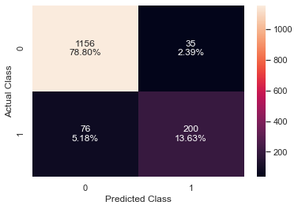

```python
conf_mat(stacking_estimator,x_test,y_test)#to plot the confusion matrix of the stacking classifier
```

- The model still misclassified 76 travel package purchasers and 35 non-travel package purchasers. This classification error is still higher than that of XGBoost Tuned.

## Comparing all Models

```python
# defining list of models
models = [dtree,bagging,rf_estimator,dtree_tuned,bagging_estimator_tuned,rf_estimator_tuned,abc, gbc, xgb, abc_tuned, gbc_tuned, xgb_tuned,stacking_estimator]

# defining empty lists to add train and test results
train_acc = []
test_acc = []
train_recall = []
test_recall = []
train_precision = []
test_precision = []
train_f1_score=[]
test_f1_score=[]


# looping through all the models to get the accuracy, precall,precision, and f1 scores
for model in models:
    j = model_perf(model,False)
    train_acc.append(np.round(j[0],2))
    test_acc.append(np.round(j[1],2))
    train_recall.append(np.round(j[2],2))
    test_recall.append(np.round(j[3],2))
    train_precision.append(np.round(j[4],2))
    test_precision.append(np.round(j[5],2))
    train_f1_score.append(np.round(j[6],2))
    test_f1_score.append(np.round(j[7],2))
#return score_list
```

```python
#To put the various models performances into a dataframe
comparison_frame = pd.DataFrame({'Model':['Decision Tree with default parameters','Bagging with default parameters', 'Random Forest with default parameters','Decision Tree Tuned','Bagging Tuned','Random Forest Tuned','AdaBoost with default parameters',
                                          'Gradient Boosting with default parameters',
                                          'XGBoost with default parameters','AdaBoost Tuned','Gradient Boosting Tuned','XGBoost Tuned','Stacking Classifier'],
                                          'Train_Accuracy': train_acc,'Test_Accuracy': test_acc,
                                          'Train_Recall':train_recall,'Test_Recall':test_recall,
                                          'Train_Precision':train_precision,'Test_Precision':test_precision,'Train_F1_Score':train_f1_score,'Test_F1_Score':test_f1_score})
comparison_frame
```

|  | Model | Train_Accuracy | Test_Accuracy | Train_Recall | Test_Recall | Train_Precision | Test_Precision | Train_F1_Score | Test_F1_Score |
| --- | --- | --- | --- | --- | --- | --- | --- | --- | --- |
| 0 | Decision Tree with default parameters | 1.00 | 0.88 | 1.00 | 0.68 | 1.00 | 0.70 | 1.00 | 0.69 |
| 1 | Bagging with default parameters | 0.99 | 0.91 | 0.97 | 0.62 | 1.00 | 0.89 | 0.99 | 0.73 |
| 2 | Random Forest with default parameters | 1.00 | 0.91 | 1.00 | 0.57 | 1.00 | 0.95 | 1.00 | 0.71 |
| 3 | Decision Tree Tuned | 0.79 | 0.81 | 0.57 | 0.55 | 0.45 | 0.49 | 0.50 | 0.52 |
| 4 | Bagging Tuned | 1.00 | 0.93 | 1.00 | 0.65 | 1.00 | 0.93 | 1.00 | 0.76 |
| 5 | Random Forest Tuned | 0.94 | 0.88 | 0.90 | 0.63 | 0.82 | 0.72 | 0.86 | 0.67 |
| 6 | AdaBoost with default parameters | 0.84 | 0.85 | 0.32 | 0.33 | 0.68 | 0.72 | 0.44 | 0.45 |
| 7 | Gradient Boosting with default parameters | 0.89 | 0.87 | 0.44 | 0.39 | 0.89 | 0.80 | 0.59 | 0.53 |
| 8 | XGBoost with default parameters | 1.00 | 0.93 | 1.00 | 0.68 | 1.00 | 0.89 | 1.00 | 0.77 |
| 9 | AdaBoost Tuned | 0.99 | 0.89 | 0.96 | 0.65 | 0.99 | 0.74 | 0.97 | 0.69 |
| 10 | Gradient Boosting Tuned | 0.92 | 0.89 | 0.62 | 0.50 | 0.94 | 0.83 | 0.75 | 0.63 |
| 11 | XGBoost Tuned | 1.00 | 0.93 | 1.00 | 0.73 | 1.00 | 0.89 | 1.00 | 0.80 |
| 12 | Stacking Classifier | 1.00 | 0.92 | 0.99 | 0.72 | 0.99 | 0.85 | 0.99 | 0.78 |

## Conclusion

- From the table above, it is clear that XGBoost Tuned model gave the best f1_score of 0.80 on the test set and good accuracy also of 0.93. We will therefore be going with this model.
- As shown by our best model (XGBoost Tuned),Executive Designation, Passport, and Senior Manager Designation are the top three most important features determining whether a customer will purchase a travel package or not.

**CUSTOMER PROFILE**

- Basic: Low income earners(customers earning average of 20,000 monthly), All Ages, Executive Designation
- Deluxe: customers that generally earn monthly income between 20,001-24,999, not less than 22 years, Managers designation
- Standard: customers that generally earn monthly income between 25,000-30,000, All Ages, Senior Managers Designation
- Super Deluxe: Customers that generally earn between 30,001 and 34,999 monthly, not less than 28 years, and AVP designation
- King: customers that generally earn 35,000 and above monthly income, not less than 26 years old, and VP designation